# HIV and Medicaid Expansion

EDA

Author

Mike Aguilar

Published

August 11, 2025

# Housekeeping

## Data Load

Load in the data we’ve already compiled and cleaned.

CAUTION: I’ve pushed DataClean.rds from the DataPrep.qmd to shinyapps.io server. If we change anything in the DataPrep file, we need to re-commit to the server.

# Was there a visible policy impact?

## Time Series plots

- I want to see the evolution of the measures (Deaths, etc..) over time.
- I’m looking to see whether or not there appeared to be a jump around the medicaid expansion date (i.e. treatment).
- There are way too many combinations for me to produce all of the plots. We have around 39 states that were treated at some point in the sample, 2 sexes, 5 measures, 3 metrics, and 21 age groups [actually, we should be careful not to double count All Ages when do the analysis]. Regardless, it’s too many images to scan through.
- So, I created some interactive apps for us to explore.
- Caution: I’m using a free service so the apps can be slow to download.
- If you double click on a state in the legend, only that one shows up. Then you can click once to add others.
- I set it up so that you can zoom in / out and download a JPG for reference.

### Levels

This app has the values of each measure/metric with no adjustment.

[▶ Launch App](https://mikeaguilar.shinyapps.io/edaapp-timeseries-level/)

Do you see any differences before vs after the policy changes?

### De Meaned

Since the units differ by state, I demeaned to facilitate comparison. Specifically, I demeaned by the unit specific pre treatment average of val. That pre-treatment avg is computed as the avg(val|10yrs prior to treatment). Note: I originally used the entire pre treatment period, but 1) there were huge trends occurring in the 1990s that may not be relevant, 2) that implied that there was an unbalanced panel of values since the data began at the same date yet some were treated at different dates, so the years over which averaged was uneven. By unit specific I am referring to measure/metric/age/sex/location. We don’t want to use the entire time series since doing so might mute the treatment effect we are trying to see.

[▶ Launch App](https://mikeaguilar.shinyapps.io/edaapp-timeseries-demean/)

Do you see any differences before vs after the policy changes?

Note: You might see that the line is negative and then positive. That is an artifact of the demeaning.

## Density comparison

Let’s focus on allages and exclude the US as a whole; i.e. only individual states. Also focus on only 15 yrs pre event

Verified that my filtered “temp” object has no NA’s in any of its columns.

| na_location_name | na_measure_id | na_measure_name | na_location_id | na_sex_id | na_sex_name | na_age_id | na_age_name | na_cause_id | na_cause_name | na_metric_id | na_metric_name | na_year | na_val | na_upper | na_lower | na_expansion_year | na_base_mean | na_val_demean | na_eventime |
| --- | --- | --- | --- | --- | --- | --- | --- | --- | --- | --- | --- | --- | --- | --- | --- | --- | --- | --- | --- |
| 0 | 0 | 0 | 0 | 0 | 0 | 0 | 0 | 0 | 0 | 0 | 0 | 0 | 0 | 0 | 0 | 0 | 0 | 0 | 0 |

### Death Rate

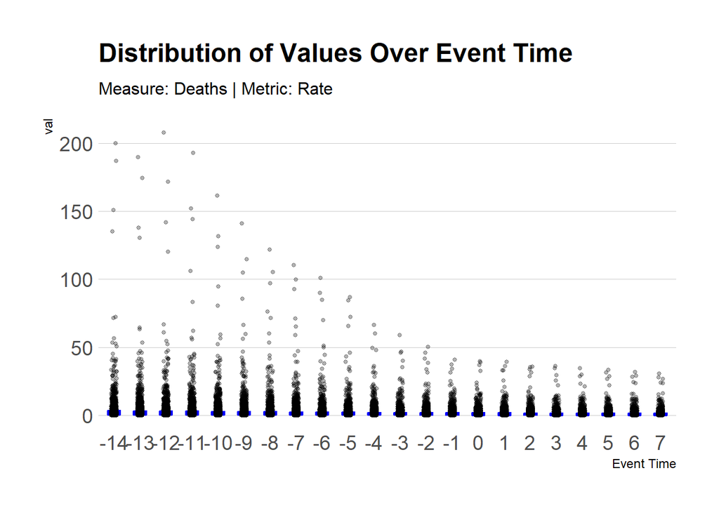

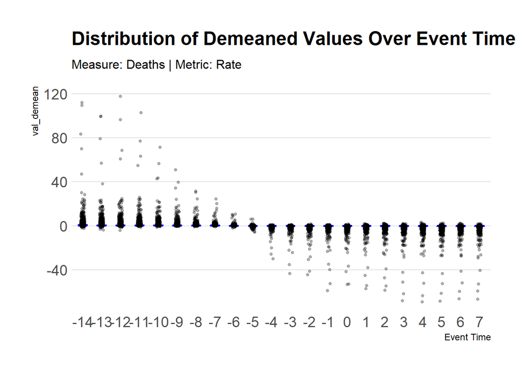

Wow. That’s ridiculous outliers. Maybe I’m doing something wrong.

Let’s compute summary stats. Focus on Deaths, Rate, pooling across all treated units.

```
     Min.   1st Qu.    Median      Mean   3rd Qu.      Max.
-69.31671  -0.15315  -0.01102  -0.13345   0.06203 117.46659
```

Yeah. Crazy wild.

Is it all states? Let’s look at the IQR (Inter Quartile Range) of the demeaned death rate in event time. We are looking to see if the range (IQR) is different across states. And if that varied through time. The IQR is taken across each of the age/sex units within a state and within a year.

IQR of DeMeaned Death Rate in Event Time

| location_name | -14 | -13 | -12 | -11 | -10 | -9 | -8 | -7 | -6 | -5 | -4 | -3 | -2 | -1 | 0 | 1 | 2 | 3 | 4 | 5 | 6 | 7 |
| --- | --- | --- | --- | --- | --- | --- | --- | --- | --- | --- | --- | --- | --- | --- | --- | --- | --- | --- | --- | --- | --- | --- |
| Alaska | 0.5 | 0.6 | 0.6 | 0.4 | 0.3 | 0.3 | 0.2 | 0.2 | 0.0 | 0.1 | 0.2 | 0.2 | 0.2 | 0.3 | 0.4 | 0.4 | 0.6 | 0.6 | 0.6 | 0.6 | 0.6 | NA |
| Arizona | 0.9 | 0.7 | 0.5 | 0.6 | 0.5 | 0.3 | 0.4 | 0.2 | 0.1 | 0.1 | 0.2 | 0.3 | 0.4 | 0.5 | 0.5 | 0.5 | 0.7 | 0.8 | 0.8 | 0.9 | 0.8 | 0.9 |
| Arkansas | 0.7 | 0.4 | 0.4 | 0.5 | 0.3 | 0.5 | 0.4 | 0.5 | 0.2 | 0.0 | 0.3 | 0.4 | 0.6 | 0.7 | 0.7 | 0.7 | 0.8 | 1.0 | 1.3 | 1.0 | 1.3 | 1.3 |
| California | 1.0 | 1.1 | 0.9 | 0.8 | 0.9 | 0.5 | 0.6 | 0.3 | 0.1 | 0.1 | 0.5 | 0.5 | 0.7 | 0.7 | 0.5 | 0.6 | 0.6 | 0.7 | 0.7 | 1.0 | 1.0 | 1.0 |
| Colorado | 0.5 | 0.4 | 0.4 | 0.3 | 0.3 | 0.2 | 0.2 | 0.1 | 0.0 | 0.0 | 0.1 | 0.2 | 0.3 | 0.3 | 0.4 | 0.4 | 0.5 | 0.5 | 0.5 | 0.6 | 0.6 | 0.6 |
| Connecticut | 1.3 | 1.8 | 1.5 | 1.4 | 1.6 | 1.0 | 0.7 | 0.4 | 0.1 | 0.2 | 0.6 | 0.6 | 0.7 | 1.0 | 1.1 | 1.1 | 1.3 | 1.3 | 1.3 | 1.4 | 1.4 | 1.4 |
| Delaware | 2.1 | 1.7 | 2.0 | 1.5 | 1.4 | 1.2 | 1.0 | 0.7 | 0.2 | 0.2 | 0.5 | 1.2 | 1.2 | 1.4 | 1.6 | 1.9 | 2.4 | 2.3 | 2.4 | 2.5 | 2.7 | 2.8 |
| District of Columbia | 11.4 | 6.2 | 8.3 | 10.5 | 9.0 | 6.9 | 7.2 | 5.2 | 1.5 | 0.6 | 5.0 | 8.0 | 9.5 | 11.0 | 13.0 | 14.9 | 14.7 | 17.1 | 17.7 | 17.8 | 17.1 | 17.0 |
| Hawaii | 0.6 | 0.5 | 0.4 | 0.4 | 0.4 | 0.3 | 0.3 | 0.2 | 0.1 | 0.0 | 0.2 | 0.3 | 0.4 | 0.5 | 0.6 | 0.6 | 0.7 | 0.7 | 0.8 | 0.8 | 0.7 | 0.8 |
| Idaho | 0.4 | 0.3 | 0.3 | 0.3 | 0.1 | 0.1 | 0.1 | 0.1 | 0.0 | 0.0 | 0.1 | 0.1 | 0.1 | 0.1 | 0.1 | 0.1 | NA | NA | NA | NA | NA | NA |
| Illinois | 1.2 | 1.1 | 1.0 | 0.8 | 0.7 | 0.5 | 0.4 | 0.1 | 0.1 | 0.3 | 0.3 | 0.5 | 0.5 | 0.6 | 0.9 | 0.9 | 1.2 | 1.2 | 1.3 | 1.4 | 1.3 | 1.4 |
| Indiana | 0.3 | 0.3 | 0.3 | 0.2 | 0.2 | 0.2 | 0.2 | 0.2 | 0.1 | 0.1 | 0.2 | 0.1 | 0.2 | 0.2 | 0.3 | 0.3 | 0.3 | 0.4 | 0.6 | 0.6 | 0.6 | NA |
| Iowa | 0.3 | 0.2 | 0.2 | 0.2 | 0.2 | 0.2 | 0.1 | 0.1 | 0.0 | 0.0 | 0.1 | 0.2 | 0.2 | 0.2 | 0.2 | 0.2 | 0.3 | 0.3 | 0.3 | 0.3 | 0.4 | 0.4 |
| Kentucky | 0.3 | 0.5 | 0.5 | 0.4 | 0.2 | 0.2 | 0.3 | 0.1 | 0.2 | 0.0 | 0.1 | 0.3 | 0.3 | 0.4 | 0.4 | 0.5 | 0.5 | 0.5 | 0.5 | 0.6 | 0.6 | 0.7 |
| Louisiana | 2.2 | 2.8 | 2.2 | 2.3 | 1.7 | 1.2 | 0.9 | 0.7 | 0.2 | 0.7 | 0.5 | 0.5 | 1.1 | 1.0 | 1.5 | 1.6 | 1.9 | 2.7 | 2.5 | 2.6 | NA | NA |
| Maine | 0.6 | 0.5 | 0.4 | 0.4 | 0.3 | 0.1 | 0.0 | 0.0 | 0.0 | 0.0 | 0.1 | 0.1 | 0.1 | 0.2 | 0.1 | 0.2 | 0.2 | NA | NA | NA | NA | NA |
| Maryland | 1.6 | 2.0 | 2.3 | 2.9 | 2.2 | 2.5 | 1.3 | 0.4 | 0.3 | 0.2 | 1.0 | 1.3 | 1.7 | 2.5 | 2.6 | 3.1 | 3.3 | 2.9 | 3.0 | 3.1 | 3.1 | 3.3 |
| Massachusetts | 1.1 | 1.2 | 1.1 | 0.8 | 0.7 | 0.6 | 0.5 | 0.2 | 0.1 | 0.1 | 0.4 | 0.7 | 0.5 | 0.7 | 0.6 | 0.6 | 0.8 | 0.9 | 0.9 | 1.1 | 1.0 | 1.0 |
| Michigan | 0.5 | 0.6 | 0.6 | 0.5 | 0.5 | 0.4 | 0.3 | 0.2 | 0.1 | 0.1 | 0.2 | 0.4 | 0.3 | 0.5 | 0.6 | 0.6 | 0.7 | 0.7 | 0.8 | 0.8 | 0.8 | 0.8 |
| Minnesota | 0.4 | 0.2 | 0.2 | 0.3 | 0.2 | 0.3 | 0.2 | 0.1 | 0.0 | 0.0 | 0.1 | 0.2 | 0.3 | 0.3 | 0.3 | 0.4 | 0.4 | 0.4 | 0.4 | 0.4 | 0.4 | 0.4 |
| Missouri | 0.8 | 0.5 | 0.5 | 0.3 | 0.2 | 0.2 | 0.1 | 0.1 | 0.0 | 0.1 | 0.1 | 0.1 | 0.2 | 0.2 | 0.2 | NA | NA | NA | NA | NA | NA | NA |
| Montana | 0.3 | 0.3 | 0.3 | 0.3 | 0.2 | 0.2 | 0.1 | 0.1 | 0.0 | 0.1 | 0.1 | 0.1 | 0.2 | 0.2 | 0.2 | 0.3 | 0.3 | 0.3 | 0.3 | 0.3 | NA | NA |
| Nebraska | 0.6 | 0.6 | 0.5 | 0.3 | 0.2 | 0.2 | 0.1 | 0.1 | 0.0 | 0.0 | 0.1 | 0.1 | 0.2 | 0.1 | 0.2 | 0.2 | NA | NA | NA | NA | NA | NA |
| Nevada | 1.3 | 1.0 | 0.8 | 0.9 | 0.8 | 0.7 | 0.6 | 0.3 | 0.1 | 0.1 | 0.3 | 0.7 | 0.7 | 0.7 | 0.9 | 1.0 | 0.9 | 1.0 | 1.1 | 1.4 | 1.3 | 1.3 |
| New Hampshire | 0.3 | 0.2 | 0.2 | 0.3 | 0.3 | 0.3 | 0.2 | 0.1 | 0.0 | 0.0 | 0.1 | 0.2 | 0.3 | 0.3 | 0.2 | 0.2 | 0.3 | 0.3 | 0.4 | 0.4 | 0.4 | 0.5 |
| New Jersey | 2.7 | 2.0 | 1.8 | 1.2 | 1.7 | 1.4 | 0.4 | 0.6 | 0.1 | 0.5 | 0.9 | 1.0 | 1.3 | 1.3 | 1.8 | 1.8 | 2.0 | 2.3 | 2.5 | 2.5 | 2.6 | 2.7 |
| New Mexico | 0.4 | 0.3 | 0.3 | 0.3 | 0.2 | 0.2 | 0.2 | 0.1 | 0.2 | 0.0 | 0.1 | 0.2 | 0.3 | 0.3 | 0.3 | 0.4 | 0.5 | 0.5 | 0.5 | 0.5 | 0.6 | 0.6 |
| New York | 4.0 | 3.3 | 2.8 | 2.7 | 3.1 | 2.4 | 1.2 | 0.6 | 0.2 | 0.1 | 0.8 | 1.5 | 2.0 | 2.1 | 2.4 | 2.8 | 3.1 | 3.8 | 3.8 | 3.8 | 3.8 | 3.9 |
| North Dakota | 0.2 | 0.2 | 0.2 | 0.1 | 0.1 | 0.1 | 0.1 | 0.1 | 0.0 | 0.0 | 0.1 | 0.1 | 0.1 | 0.1 | 0.2 | 0.2 | 0.2 | 0.3 | 0.3 | 0.3 | 0.3 | 0.3 |
| Ohio | 0.3 | 0.1 | 0.2 | 0.3 | 0.2 | 0.4 | 0.2 | 0.1 | 0.1 | 0.0 | 0.2 | 0.2 | 0.2 | 0.3 | 0.2 | 0.3 | 0.3 | 0.4 | 0.4 | 0.5 | 0.5 | 0.5 |
| Oklahoma | 0.8 | 0.7 | 0.6 | 0.3 | 0.3 | 0.2 | 0.1 | 0.1 | 0.0 | 0.1 | 0.1 | 0.1 | 0.1 | 0.2 | 0.2 | NA | NA | NA | NA | NA | NA | NA |
| Oregon | 0.5 | 0.5 | 0.5 | 0.4 | 0.3 | 0.3 | 0.2 | 0.1 | 0.0 | 0.0 | 0.2 | 0.2 | 0.2 | 0.3 | 0.4 | 0.4 | 0.4 | 0.5 | 0.6 | 0.5 | 0.6 | 0.6 |
| Pennsylvania | 1.1 | 1.1 | 1.2 | 1.1 | 0.7 | 0.6 | 0.7 | 0.2 | 0.1 | 0.2 | 0.3 | 0.6 | 0.6 | 0.9 | 1.0 | 1.0 | 1.1 | 1.2 | 1.3 | 1.1 | 1.1 | NA |
| Rhode Island | 1.3 | 1.1 | 1.0 | 0.9 | 0.7 | 0.5 | 0.3 | 0.3 | 0.1 | 0.0 | 0.2 | 0.4 | 0.5 | 0.6 | 0.8 | 0.9 | 1.1 | 1.1 | 1.2 | 1.1 | 1.2 | 1.3 |
| Utah | 0.5 | 0.5 | 0.4 | 0.3 | 0.2 | 0.1 | 0.1 | 0.1 | 0.0 | 0.0 | 0.1 | 0.1 | 0.1 | 0.2 | 0.2 | 0.2 | NA | NA | NA | NA | NA | NA |
| Vermont | 0.3 | 0.3 | 0.3 | 0.2 | 0.2 | 0.2 | 0.1 | 0.1 | 0.0 | 0.0 | 0.1 | 0.1 | 0.2 | 0.2 | 0.2 | 0.3 | 0.3 | 0.3 | 0.3 | 0.4 | 0.3 | 0.4 |
| Virginia | 1.2 | 1.2 | 1.0 | 0.8 | 0.6 | 0.3 | 0.1 | 0.2 | 0.0 | 0.2 | 0.2 | 0.2 | 0.3 | 0.3 | 0.4 | 0.4 | 0.5 | NA | NA | NA | NA | NA |
| Washington | 0.5 | 0.3 | 0.4 | 0.4 | 0.4 | 0.3 | 0.2 | 0.2 | 0.0 | 0.0 | 0.2 | 0.3 | 0.3 | 0.4 | 0.4 | 0.4 | 0.4 | 0.5 | 0.5 | 0.5 | 0.6 | 0.6 |
| West Virginia | 0.2 | 0.3 | 0.2 | 0.2 | 0.2 | 0.2 | 0.2 | 0.2 | 0.1 | 0.0 | 0.2 | 0.2 | 0.3 | 0.3 | 0.4 | 0.4 | 0.5 | 0.5 | 0.6 | 0.6 | 0.6 | 0.6 |

Wow. Yep. DC by far is crazy wild. NY and MD after that.

What about the demean death rate itself? Within each event time period, taking the mean across all the units (age, sex, states). Negative values imply that the death rate for that state in that year was lower than that states pre-treatment avg death rate.

Note about NA: Don’t forget this is EVENT TIME. So an NA at Event Time 7 means that we don’t have date 7yrs past the treatment (e.g. if treated in 2020, we don’t have 2027 data yet)

Cross Sectional Mean of Unit-DeMeaned Death Rate in Event Time

| location_name | -14 | -13 | -12 | -11 | -10 | -9 | -8 | -7 | -6 | -5 | -4 | -3 | -2 | -1 | 0 | 1 | 2 | 3 | 4 | 5 | 6 | 7 |
| --- | --- | --- | --- | --- | --- | --- | --- | --- | --- | --- | --- | --- | --- | --- | --- | --- | --- | --- | --- | --- | --- | --- |
| Alaska | 0.5 | 0.5 | 0.4 | 0.3 | 0.2 | 0.2 | 0.2 | 0.1 | 0.0 | -0.1 | -0.1 | -0.2 | -0.2 | -0.2 | -0.3 | -0.3 | -0.3 | -0.4 | -0.4 | -0.4 | -0.4 | NA |
| Arizona | 1.0 | 0.9 | 0.9 | 0.9 | 0.7 | 0.5 | 0.4 | 0.1 | 0.0 | -0.1 | -0.3 | -0.4 | -0.4 | -0.5 | -0.5 | -0.6 | -0.6 | -0.7 | -0.8 | -0.8 | -0.8 | -0.9 |
| Arkansas | 0.7 | 0.5 | 0.6 | 0.5 | 0.4 | 0.4 | 0.3 | 0.3 | 0.1 | 0.0 | -0.2 | -0.3 | -0.5 | -0.4 | -0.5 | -0.6 | -0.7 | -0.8 | -0.9 | -0.8 | -0.9 | -0.9 |
| California | 1.4 | 1.5 | 1.1 | 1.0 | 0.9 | 0.7 | 0.5 | 0.3 | 0.0 | -0.2 | -0.5 | -0.5 | -0.6 | -0.6 | -0.6 | -0.6 | -0.6 | -0.8 | -0.8 | -0.9 | -0.9 | -1.0 |
| Colorado | 0.7 | 0.7 | 0.7 | 0.5 | 0.5 | 0.4 | 0.3 | 0.2 | 0.0 | -0.1 | -0.2 | -0.3 | -0.4 | -0.4 | -0.4 | -0.4 | -0.5 | -0.5 | -0.5 | -0.6 | -0.6 | -0.6 |
| Connecticut | 1.9 | 1.7 | 1.6 | 1.5 | 1.3 | 0.8 | 0.5 | 0.4 | 0.0 | -0.2 | -0.5 | -0.7 | -0.8 | -0.9 | -1.0 | -1.1 | -1.2 | -1.3 | -1.4 | -1.4 | -1.4 | -1.4 |
| Delaware | 2.1 | 1.8 | 1.7 | 1.7 | 1.2 | 1.1 | 0.7 | 0.5 | 0.2 | -0.1 | -0.5 | -0.8 | -1.1 | -1.2 | -1.3 | -1.5 | -1.8 | -1.8 | -1.8 | -1.9 | -1.9 | -2.0 |
| District of Columbia | 13.6 | 11.4 | 11.9 | 11.6 | 9.2 | 6.7 | 5.3 | 3.7 | 1.8 | -0.4 | -4.1 | -6.2 | -7.2 | -9.0 | -9.3 | -9.8 | -10.0 | -11.0 | -11.3 | -11.3 | -11.2 | -11.4 |
| Hawaii | 0.8 | 0.7 | 0.6 | 0.6 | 0.5 | 0.4 | 0.3 | 0.2 | 0.1 | -0.1 | -0.2 | -0.3 | -0.4 | -0.5 | -0.5 | -0.6 | -0.6 | -0.7 | -0.7 | -0.8 | -0.8 | -0.8 |
| Idaho | 0.3 | 0.2 | 0.2 | 0.2 | 0.1 | 0.1 | 0.0 | 0.0 | 0.0 | 0.0 | 0.0 | -0.1 | -0.1 | -0.1 | -0.1 | -0.1 | NA | NA | NA | NA | NA | NA |
| Illinois | 1.3 | 1.3 | 1.1 | 1.0 | 0.8 | 0.6 | 0.5 | 0.2 | 0.2 | -0.2 | -0.3 | -0.5 | -0.6 | -0.7 | -0.8 | -0.7 | -0.9 | -1.0 | -1.0 | -1.2 | -1.1 | -1.1 |
| Indiana | 0.5 | 0.5 | 0.4 | 0.3 | 0.3 | 0.3 | 0.2 | 0.2 | 0.1 | -0.1 | -0.2 | -0.2 | -0.3 | -0.3 | -0.3 | -0.3 | -0.4 | -0.4 | -0.5 | -0.5 | -0.5 | NA |
| Iowa | 0.3 | 0.2 | 0.2 | 0.2 | 0.2 | 0.1 | 0.1 | 0.1 | 0.0 | 0.0 | -0.1 | -0.1 | -0.1 | -0.2 | -0.1 | -0.2 | -0.2 | -0.3 | -0.3 | -0.3 | -0.3 | -0.3 |
| Kentucky | 0.4 | 0.5 | 0.6 | 0.4 | 0.3 | 0.2 | 0.2 | 0.1 | 0.1 | 0.0 | -0.2 | -0.3 | -0.3 | -0.3 | -0.3 | -0.4 | -0.4 | -0.4 | -0.5 | -0.5 | -0.5 | -0.6 |
| Louisiana | 2.2 | 2.4 | 2.3 | 2.1 | 1.5 | 1.3 | 0.9 | 0.5 | -0.3 | -0.5 | -0.6 | -0.7 | -1.0 | -1.1 | -1.4 | -1.5 | -1.7 | -2.0 | -1.9 | -1.9 | NA | NA |
| Maine | 0.4 | 0.4 | 0.3 | 0.3 | 0.2 | 0.1 | 0.0 | 0.0 | 0.0 | 0.0 | 0.0 | -0.1 | -0.1 | -0.1 | -0.1 | -0.1 | -0.2 | NA | NA | NA | NA | NA |
| Maryland | 2.7 | 2.7 | 2.9 | 3.0 | 2.3 | 1.8 | 1.3 | 0.7 | 0.3 | -0.3 | -1.0 | -1.4 | -1.7 | -2.0 | -2.2 | -2.4 | -2.4 | -2.6 | -2.7 | -2.7 | -2.7 | -2.8 |
| Massachusetts | 1.4 | 1.3 | 1.2 | 1.0 | 0.9 | 0.6 | 0.5 | 0.2 | 0.0 | -0.1 | -0.3 | -0.5 | -0.6 | -0.7 | -0.7 | -0.7 | -0.8 | -0.9 | -0.9 | -1.0 | -1.0 | -1.0 |
| Michigan | 0.8 | 0.7 | 0.6 | 0.5 | 0.4 | 0.4 | 0.2 | 0.2 | 0.1 | -0.1 | -0.2 | -0.3 | -0.3 | -0.4 | -0.5 | -0.5 | -0.6 | -0.7 | -0.7 | -0.7 | -0.7 | -0.7 |
| Minnesota | 0.5 | 0.4 | 0.4 | 0.3 | 0.2 | 0.2 | 0.2 | 0.1 | 0.0 | 0.0 | -0.1 | -0.2 | -0.2 | -0.2 | -0.3 | -0.3 | -0.3 | -0.3 | -0.4 | -0.4 | -0.4 | -0.4 |
| Missouri | 0.8 | 0.7 | 0.5 | 0.4 | 0.2 | 0.1 | 0.1 | 0.0 | -0.1 | -0.1 | -0.1 | -0.1 | -0.1 | -0.1 | -0.2 | NA | NA | NA | NA | NA | NA | NA |
| Montana | 0.3 | 0.3 | 0.2 | 0.2 | 0.2 | 0.1 | 0.1 | 0.1 | 0.0 | -0.1 | -0.1 | -0.1 | -0.1 | -0.1 | -0.2 | -0.2 | -0.2 | -0.2 | -0.2 | -0.2 | NA | NA |
| Nebraska | 0.5 | 0.5 | 0.4 | 0.3 | 0.2 | 0.1 | 0.1 | 0.1 | 0.1 | 0.0 | -0.1 | -0.1 | -0.1 | -0.2 | -0.1 | -0.2 | NA | NA | NA | NA | NA | NA |
| Nevada | 1.3 | 1.0 | 0.9 | 0.9 | 0.7 | 0.7 | 0.4 | 0.3 | 0.1 | -0.1 | -0.4 | -0.5 | -0.5 | -0.7 | -0.8 | -0.9 | -0.9 | -1.1 | -1.1 | -1.2 | -1.2 | -1.2 |
| New Hampshire | 0.4 | 0.3 | 0.3 | 0.3 | 0.2 | 0.2 | 0.1 | 0.1 | 0.0 | 0.0 | -0.1 | -0.1 | -0.2 | -0.2 | -0.2 | -0.2 | -0.2 | -0.3 | -0.3 | -0.3 | -0.3 | -0.3 |
| New Jersey | 3.2 | 2.7 | 2.6 | 2.2 | 2.0 | 1.4 | 0.9 | 0.5 | 0.2 | -0.3 | -0.7 | -1.0 | -1.4 | -1.5 | -1.7 | -1.9 | -2.0 | -2.2 | -2.4 | -2.5 | -2.4 | -2.5 |
| New Mexico | 0.6 | 0.5 | 0.5 | 0.5 | 0.3 | 0.3 | 0.3 | 0.2 | 0.2 | 0.0 | -0.1 | -0.3 | -0.3 | -0.4 | -0.4 | -0.4 | -0.6 | -0.6 | -0.6 | -0.7 | -0.7 | -0.7 |
| New York | 4.3 | 3.2 | 3.2 | 2.9 | 2.4 | 1.9 | 1.1 | 0.6 | 0.2 | -0.3 | -0.9 | -1.2 | -1.7 | -2.0 | -2.2 | -2.4 | -2.6 | -2.9 | -3.0 | -3.1 | -3.0 | -3.1 |
| North Dakota | 0.2 | 0.2 | 0.2 | 0.1 | 0.1 | 0.1 | 0.1 | 0.0 | 0.0 | 0.0 | 0.0 | -0.1 | -0.1 | -0.1 | -0.1 | -0.1 | -0.2 | -0.2 | -0.2 | -0.2 | -0.2 | -0.2 |
| Ohio | 0.6 | 0.4 | 0.5 | 0.5 | 0.2 | 0.3 | 0.3 | 0.2 | 0.1 | 0.0 | -0.2 | -0.3 | -0.3 | -0.3 | -0.4 | -0.4 | -0.4 | -0.4 | -0.5 | -0.6 | -0.6 | -0.6 |
| Oklahoma | 0.9 | 0.8 | 0.6 | 0.3 | 0.3 | 0.2 | 0.2 | 0.1 | 0.0 | -0.1 | -0.2 | -0.2 | -0.2 | -0.2 | -0.2 | NA | NA | NA | NA | NA | NA | NA |
| Oregon | 0.6 | 0.6 | 0.7 | 0.7 | 0.4 | 0.3 | 0.2 | 0.1 | 0.0 | -0.1 | -0.2 | -0.3 | -0.3 | -0.3 | -0.4 | -0.4 | -0.5 | -0.5 | -0.6 | -0.6 | -0.6 | -0.6 |
| Pennsylvania | 1.3 | 1.3 | 1.1 | 1.0 | 0.7 | 0.6 | 0.5 | 0.2 | 0.1 | -0.2 | -0.4 | -0.5 | -0.4 | -0.6 | -0.7 | -0.8 | -0.9 | -1.0 | -1.1 | -1.0 | -1.0 | NA |
| Rhode Island | 1.0 | 0.8 | 0.8 | 0.8 | 0.6 | 0.4 | 0.3 | 0.2 | 0.1 | 0.0 | -0.2 | -0.4 | -0.5 | -0.5 | -0.6 | -0.7 | -0.8 | -0.8 | -0.9 | -0.9 | -0.9 | -0.9 |
| Utah | 0.5 | 0.4 | 0.3 | 0.3 | 0.2 | 0.1 | 0.1 | 0.1 | 0.0 | 0.0 | 0.0 | -0.1 | -0.1 | -0.2 | -0.1 | -0.1 | NA | NA | NA | NA | NA | NA |
| Vermont | 0.5 | 0.4 | 0.3 | 0.3 | 0.2 | 0.2 | 0.1 | 0.1 | 0.0 | 0.0 | -0.1 | -0.1 | -0.2 | -0.2 | -0.2 | -0.2 | -0.3 | -0.3 | -0.3 | -0.3 | -0.3 | -0.3 |
| Virginia | 1.2 | 1.2 | 1.0 | 0.7 | 0.6 | 0.3 | 0.1 | 0.1 | 0.0 | -0.1 | -0.2 | -0.2 | -0.3 | -0.3 | -0.3 | -0.3 | -0.4 | NA | NA | NA | NA | NA |
| Washington | 0.7 | 0.5 | 0.6 | 0.6 | 0.4 | 0.4 | 0.2 | 0.2 | 0.1 | 0.0 | -0.2 | -0.3 | -0.4 | -0.4 | -0.4 | -0.5 | -0.5 | -0.6 | -0.5 | -0.6 | -0.6 | -0.6 |
| West Virginia | 0.3 | 0.3 | 0.3 | 0.3 | 0.3 | 0.2 | 0.2 | 0.1 | 0.1 | 0.0 | -0.2 | -0.2 | -0.3 | -0.3 | -0.3 | -0.4 | -0.4 | -0.5 | -0.5 | -0.5 | -0.5 | -0.5 |

Summary

- A few states are very wild. Much more volatile and higher levels of deaths than others.
- Doesn’t seem like based on population size, since DC is the main culprit.
- Such huge variation in units implies that matching treat and control might be difficult.
- Aside from variability, it doesn’t appear like many/any of the states had a visible treatment effect. i.e. look just before and after eventtime 0 in the table above. If medicaid expansion had an impact, I’d expect there to be a difference. This was supported by the time series plots.

### Incidence

| na_location_name | na_measure_id | na_measure_name | na_location_id | na_sex_id | na_sex_name | na_age_id | na_age_name | na_cause_id | na_cause_name | na_metric_id | na_metric_name | na_year | na_val | na_upper | na_lower | na_expansion_year | na_base_mean | na_val_demean | na_eventime |
| --- | --- | --- | --- | --- | --- | --- | --- | --- | --- | --- | --- | --- | --- | --- | --- | --- | --- | --- | --- |
| 0 | 0 | 0 | 0 | 0 | 0 | 0 | 0 | 0 | 0 | 0 | 0 | 0 | 0 | 0 | 0 | 0 | 0 | 0 | 0 |

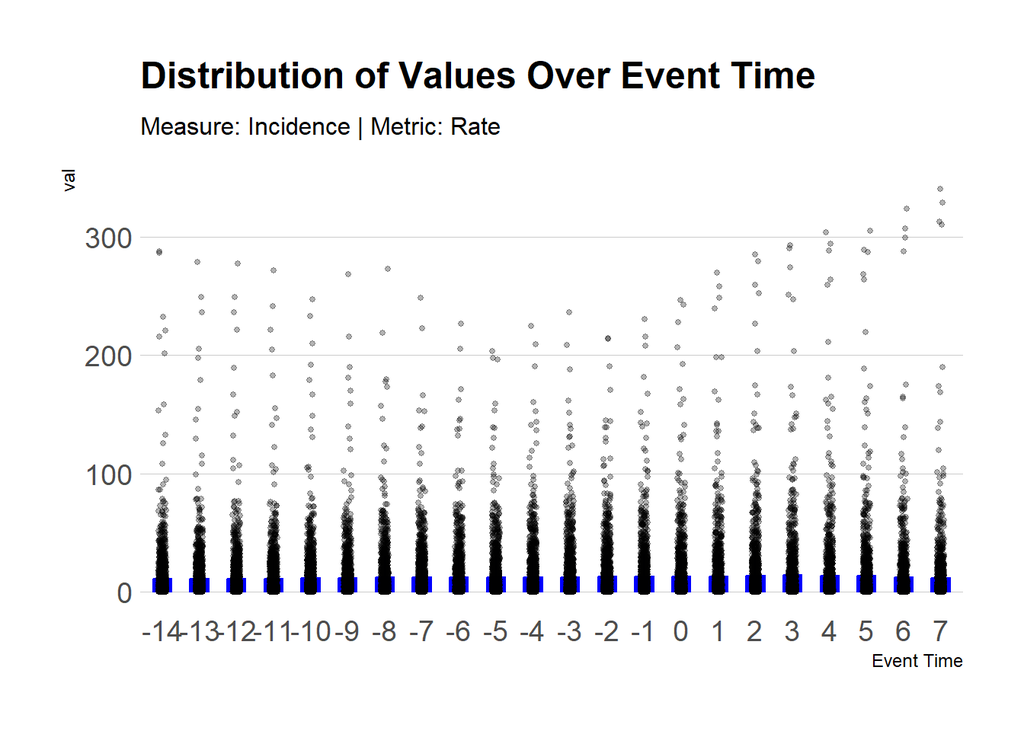

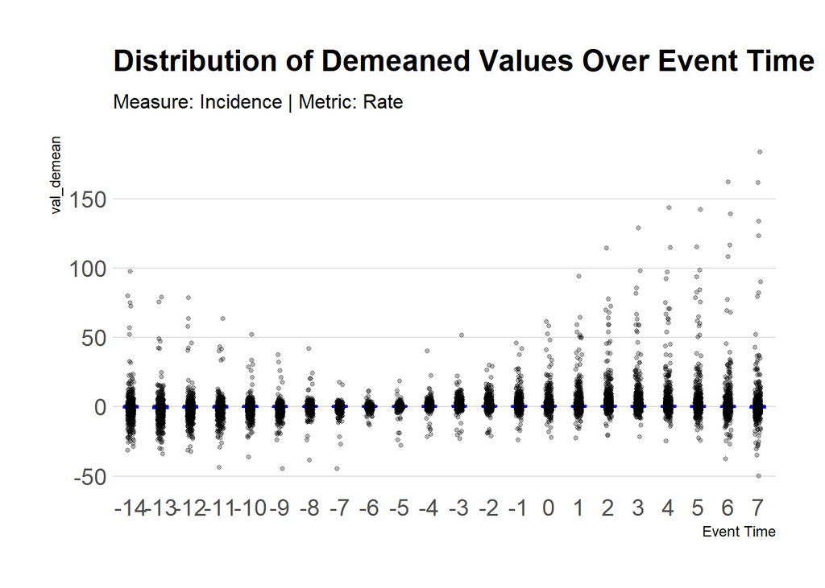

Seems like the central tendency is unchanged but the variability is wild. Regardless, there is no change around the event time.

Cross Sectional Mean of Unit-DeMeaned Incidence Rate in Event Time

| location_name | -14 | -13 | -12 | -11 | -10 | -9 | -8 | -7 | -6 | -5 | -4 | -3 | -2 | -1 | 0 | 1 | 2 | 3 | 4 | 5 | 6 | 7 |
| --- | --- | --- | --- | --- | --- | --- | --- | --- | --- | --- | --- | --- | --- | --- | --- | --- | --- | --- | --- | --- | --- | --- |
| Alaska | -1.4 | -1.2 | -1.2 | -0.9 | -1.0 | -0.5 | -0.5 | -0.3 | -0.1 | 0.1 | 0.3 | 0.5 | 0.6 | 0.8 | 1.3 | 1.8 | 2.1 | 2.2 | 2.2 | 2.5 | 2.9 | NA |
| Arizona | -1.4 | -1.8 | -1.7 | -1.6 | -1.5 | -1.5 | -0.7 | -0.9 | -0.6 | -0.2 | 0.4 | 1.5 | 1.5 | 2.1 | 2.1 | 2.8 | 3.4 | 3.6 | 3.7 | 3.7 | 4.1 | 4.6 |
| Arkansas | -2.9 | -3.0 | -2.6 | -2.2 | -1.5 | -1.4 | -0.3 | -0.4 | 0.0 | 0.1 | 0.6 | 0.9 | 1.0 | 0.9 | 0.5 | 0.7 | 1.2 | 1.0 | 0.7 | 0.2 | -0.7 | -1.7 |
| California | 0.3 | -0.5 | -0.5 | -0.7 | -0.4 | -0.6 | 0.0 | -0.5 | -0.3 | -0.2 | 0.3 | 0.5 | 0.7 | 0.5 | 1.0 | 1.6 | 2.0 | 2.1 | 2.1 | 2.1 | 2.4 | 2.8 |
| Colorado | -0.2 | -0.5 | -0.5 | -0.5 | -0.4 | -0.7 | -0.3 | -0.3 | 0.1 | -0.1 | 0.2 | 0.4 | 0.5 | 0.6 | 0.7 | 1.3 | 1.7 | 1.8 | 1.8 | 1.8 | 2.1 | 2.4 |
| Connecticut | 0.0 | -0.6 | -0.5 | -0.5 | -0.2 | -0.4 | 0.4 | 0.0 | 0.2 | 0.1 | 0.2 | 0.1 | -0.1 | -0.3 | -0.5 | -0.6 | -0.3 | -0.4 | -0.5 | -0.8 | -1.4 | -1.9 |
| Delaware | -5.1 | -5.6 | -5.0 | -4.4 | -3.1 | -2.9 | -0.9 | -1.0 | 0.0 | 0.2 | 1.2 | 2.0 | 2.2 | 2.3 | 1.7 | 1.9 | 2.7 | 2.4 | 1.7 | 0.7 | -1.1 | -3.0 |
| District of Columbia | 18.8 | 14.0 | 12.6 | 9.7 | 7.5 | 4.9 | 4.6 | 0.6 | -1.3 | -3.8 | -3.7 | -3.9 | -3.6 | -1.3 | 3.6 | 8.3 | 12.0 | 14.2 | 16.2 | 16.2 | 19.4 | 22.7 |
| Hawaii | -1.6 | -1.9 | -1.7 | -1.6 | -1.3 | -1.3 | -0.5 | -0.7 | -0.3 | 0.1 | 0.7 | 0.9 | 0.9 | 1.6 | 1.7 | 2.4 | 3.0 | 3.2 | 3.3 | 3.3 | 3.7 | 4.1 |
| Idaho | -0.7 | -0.7 | -0.5 | -0.4 | -0.2 | 0.0 | 0.1 | 0.1 | 0.0 | 0.0 | 0.1 | 0.1 | 0.0 | -0.2 | -0.5 | -0.9 | NA | NA | NA | NA | NA | NA |
| Illinois | -1.2 | -1.7 | -1.5 | -1.3 | -0.9 | -1.0 | -0.2 | -0.4 | -0.1 | 0.0 | 0.3 | 0.6 | 0.9 | 0.9 | 0.7 | 0.7 | 1.0 | 0.8 | 0.5 | 0.0 | -0.8 | -1.6 |
| Indiana | -2.3 | -2.2 | -2.1 | -1.6 | -1.6 | -0.8 | -0.8 | -0.5 | -0.5 | 0.1 | 0.5 | 0.9 | 1.5 | 1.3 | 1.9 | 2.4 | 2.6 | 2.7 | 2.7 | 3.0 | 3.4 | NA |
| Iowa | -1.2 | -1.3 | -1.1 | -1.0 | -0.7 | -0.7 | -0.2 | -0.2 | 0.0 | 0.0 | 0.3 | 0.5 | 0.5 | 0.5 | 0.5 | 0.5 | 0.5 | 0.5 | 0.3 | 0.1 | -0.3 | -0.6 |
| Kentucky | -2.2 | -2.3 | -2.1 | -1.8 | -1.4 | -1.3 | -0.5 | -0.5 | -0.1 | 0.1 | 0.6 | 1.0 | 1.1 | 1.0 | 0.8 | 0.9 | 1.0 | 0.9 | 0.6 | 0.2 | -0.5 | -1.2 |
| Louisiana | -3.1 | -3.4 | -3.0 | -4.2 | -3.0 | -4.5 | -4.0 | -4.1 | -1.4 | 0.7 | 2.2 | 3.3 | 4.1 | 6.6 | 8.7 | 9.4 | 9.9 | 9.9 | 11.4 | 13.0 | NA | NA |
| Maine | -1.8 | -1.2 | -1.1 | -0.8 | -0.6 | -0.2 | 0.1 | 0.2 | 0.2 | 0.1 | 0.1 | 0.2 | 0.1 | -0.2 | -0.5 | -1.1 | -1.6 | NA | NA | NA | NA | NA |
| Maryland | 1.1 | -0.1 | -0.1 | -0.1 | 0.4 | -0.1 | 1.1 | 0.4 | 0.3 | -0.3 | -0.3 | -0.2 | -0.6 | -0.9 | -0.9 | -0.8 | 0.0 | 0.0 | -0.3 | -0.8 | -1.9 | -3.0 |
| Massachusetts | 1.9 | 1.1 | 0.8 | 0.6 | 0.6 | 0.2 | 0.3 | 0.1 | 0.0 | -0.2 | -0.4 | -0.4 | -0.3 | 0.1 | 0.0 | 0.3 | 0.6 | 0.7 | 0.8 | 0.8 | 1.1 | 1.3 |
| Michigan | -1.8 | -2.0 | -1.8 | -1.6 | -1.2 | -1.1 | -0.3 | -0.4 | 0.0 | 0.1 | 0.5 | 0.9 | 0.9 | 0.7 | 0.6 | 0.6 | 0.8 | 0.6 | 0.3 | -0.1 | -0.8 | -1.5 |
| Minnesota | -0.3 | -0.6 | -0.7 | -0.6 | -0.3 | -0.5 | -0.3 | -0.6 | -0.4 | -0.1 | 0.1 | 0.5 | 0.7 | 0.9 | 0.9 | 1.1 | 1.3 | 1.4 | 1.4 | 1.4 | 1.6 | 1.7 |
| Missouri | 2.3 | 2.8 | 2.3 | 1.8 | 1.3 | 0.8 | 0.4 | 0.0 | -0.3 | -0.4 | -0.4 | -0.5 | -0.5 | -0.5 | -0.6 | NA | NA | NA | NA | NA | NA | NA |
| Montana | -1.5 | -1.3 | -1.1 | -1.0 | -0.5 | -0.5 | -0.3 | -0.2 | 0.1 | 0.3 | 0.3 | 0.3 | 0.3 | 0.2 | 0.4 | 0.3 | 0.2 | 0.0 | -0.4 | -0.7 | NA | NA |
| Nebraska | -0.9 | -0.9 | -0.7 | -0.6 | -0.2 | 0.1 | 0.2 | 0.2 | 0.0 | -0.1 | 0.2 | 0.1 | -0.1 | -0.3 | -0.8 | -1.3 | NA | NA | NA | NA | NA | NA |
| Nevada | -3.3 | -3.5 | -3.1 | -2.7 | -2.0 | -1.9 | -0.7 | -0.8 | -0.2 | 0.1 | 0.9 | 1.4 | 1.6 | 1.6 | 1.6 | 1.7 | 2.0 | 1.8 | 1.4 | 0.7 | -0.3 | -1.5 |
| New Hampshire | -1.3 | -1.4 | -1.2 | -1.1 | -0.8 | -0.9 | -0.5 | -0.5 | -0.2 | 0.0 | 0.3 | 0.6 | 0.9 | 1.0 | 1.1 | 1.2 | 1.5 | 1.6 | 1.8 | 1.7 | 1.9 | 2.1 |
| New Jersey | 4.5 | 3.0 | 2.1 | 1.7 | 1.1 | 0.5 | 1.1 | 0.5 | 0.5 | -0.5 | -0.5 | -0.8 | -0.7 | -1.1 | -0.2 | 0.8 | 1.6 | 2.1 | 2.3 | 2.3 | 3.0 | 3.6 |
| New Mexico | -2.7 | -2.9 | -2.5 | -2.1 | -1.5 | -1.4 | -0.4 | -0.4 | -0.1 | 0.1 | 0.6 | 0.9 | 1.0 | 1.2 | 1.1 | 1.1 | 1.3 | 1.2 | 0.9 | 0.5 | -0.3 | -1.1 |
| New York | 1.7 | 0.4 | 0.3 | 0.3 | 0.7 | 0.1 | 1.2 | 0.4 | 0.4 | -0.2 | -0.2 | -0.4 | -0.8 | -1.1 | -1.6 | -1.8 | -1.2 | -1.4 | -1.7 | -2.2 | -3.1 | -4.0 |
| North Dakota | -1.0 | -1.0 | -0.9 | -0.8 | -0.6 | -0.5 | -0.2 | -0.2 | 0.0 | 0.1 | 0.2 | 0.3 | 0.4 | 0.4 | 0.3 | 0.2 | 0.2 | 0.2 | 0.1 | 0.0 | -0.3 | -0.5 |
| Ohio | -2.3 | -2.4 | -2.2 | -1.9 | -1.4 | -1.3 | -0.5 | -0.5 | -0.1 | 0.0 | 0.6 | 1.0 | 1.2 | 1.2 | 1.0 | 1.1 | 1.1 | 0.9 | 0.5 | 0.1 | -0.6 | -1.4 |
| Oklahoma | -0.9 | -0.6 | -0.6 | -0.1 | 0.1 | 0.2 | 0.2 | 0.2 | 0.2 | 0.5 | 0.3 | 0.0 | -0.5 | -1.3 | -2.1 | NA | NA | NA | NA | NA | NA | NA |
| Oregon | -1.3 | -1.5 | -1.4 | -1.2 | -0.9 | -0.9 | -0.3 | -0.3 | -0.1 | 0.1 | 0.5 | 0.7 | 0.7 | 0.5 | 0.5 | 0.6 | 0.8 | 0.6 | 0.4 | 0.1 | -0.5 | -1.1 |
| Pennsylvania | -1.9 | -1.7 | -1.5 | -1.0 | -1.1 | -0.2 | -0.5 | -0.1 | -0.1 | 0.3 | 0.5 | 0.6 | 0.5 | 0.2 | 0.4 | 0.5 | 0.2 | -0.1 | -0.6 | -1.4 | -2.3 | NA |
| Rhode Island | -2.9 | -3.1 | -2.8 | -2.4 | -1.7 | -1.6 | -0.5 | -0.6 | -0.1 | 0.1 | 0.7 | 1.1 | 1.3 | 1.4 | 1.2 | 1.2 | 1.4 | 1.1 | 0.8 | 0.2 | -0.8 | -1.7 |
| Utah | -1.0 | -1.0 | -0.8 | -0.7 | -0.4 | -0.2 | 0.0 | 0.0 | 0.1 | 0.1 | 0.3 | 0.2 | 0.1 | -0.2 | -0.6 | -1.1 | NA | NA | NA | NA | NA | NA |
| Vermont | -1.6 | -1.7 | -1.5 | -1.3 | -1.0 | -0.9 | -0.4 | -0.3 | -0.1 | 0.1 | 0.4 | 0.6 | 0.7 | 0.8 | 0.7 | 0.6 | 0.7 | 0.6 | 0.4 | 0.2 | -0.3 | -0.7 |
| Virginia | -1.5 | -1.3 | -1.7 | -1.3 | -1.6 | -1.1 | -1.0 | -1.0 | -0.6 | -0.2 | 0.7 | 1.3 | 1.6 | 1.8 | 1.8 | 2.2 | 2.8 | NA | NA | NA | NA | NA |
| Washington | -0.9 | -1.1 | -0.9 | -0.9 | -0.6 | -0.6 | 0.0 | -0.2 | 0.1 | 0.0 | 0.2 | 0.3 | 0.5 | 0.4 | 0.2 | 0.1 | 0.3 | 0.2 | 0.0 | -0.3 | -0.7 | -1.2 |
| West Virginia | -2.1 | -2.2 | -1.9 | -1.7 | -1.2 | -1.1 | -0.4 | -0.4 | -0.1 | 0.0 | 0.5 | 0.8 | 0.9 | 0.9 | 0.8 | 0.8 | 1.0 | 0.9 | 0.6 | 0.3 | -0.3 | -1.0 |

Summary:

- Similar to Deaths, I’m not seeing much in the EDA to signal that there was an expansion year effect.
- DC jumped at event time. But this is the wildest “state”. Need to check stat sig.
- There is something weird at 4-5yrs prior to the expansion year. There is often a jump higher. Examples: Louisianna (2016 treatment). VA (2019 treatment). So I don’t think it’s a calendar year effect. If there is something here, it’s an event time effect. Q: Is there some type of transition period as a state adapts to this new medicaid policy?

To Do:

- Other measures
- Other metrics